# Your Digest for Wednesday, Jul 19, 2023 11:59 PM

Isotonic exercise - "same tone" - muscle contracts against a constant load (like bicep curls, cycling machine etc)

See [[2023-SEMPaper#Heart failure]]

- Due to **reduced EF**
- or diastolic dysfunction - **preserved EF**.  
  In early stages, compensatory mechanisms maintain cardiac output and peripheral perfusion. despite progressive myocardial dysfunction. After a particular point, the compensatory mechanisms become detrimental to heart function.

# Pharmacotherapy in heart failure

**Angdrogen replacement will not restore fertility** in men with hypopituitarism. (because LH and FSH which are important for fertility will not be replaced. )

### First line antihypertensives - AACT

First line drugs show similar mortality benefit.  
Moreover,

> Multiple guidelines and meta-analyses conclude that the degree of blood pressure reduction, not the choice of antihypertensive medication, is the major determinant of reduction in cardiovascular risk in patients with hypertension

Compelling indications :  
ACEi - Diabetic nephropathy, CKD  
Beta blockers - IHD or HFrEF

Platelet derived thromboxane promotes platelet clot formation while endothelium derived prostacylin inhibits clot formation.  
They are both synthesized as products of the [[General Pharmacology#Prostaglandin and COX pathway|COX pathway]] in the respective cells:

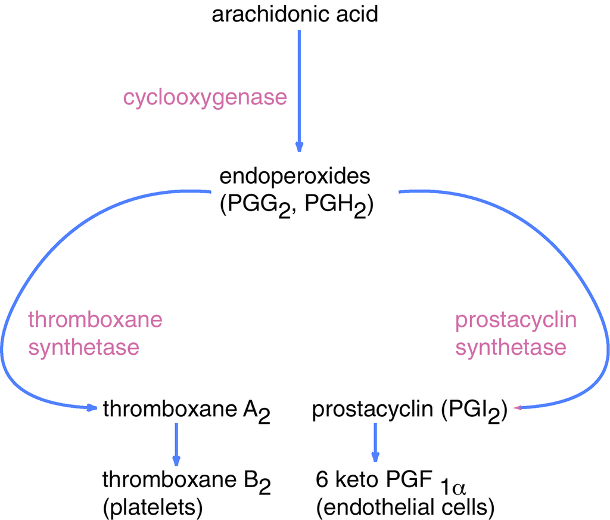

**Cholecystokinin** - promote pancreatic enzyme secretion, and gall bladder contraction.  
*Vasoactive intestinal peptide (VIP)* -> Secreted by enteric **NERVES** -> Neurotransmitter, Stimulates insulin release, splanchnic vasolidation and intestinal secretion of water and electrolytes; also *relaxes smooth muscles*, including the lower esophageal sphincter and colon  
*Glucose dependent insulinotropic polypeptide* - GIP - - From duodenum, gastric antrum and ileum - stimulated by *intraduodenal* glucose -> incretin effect. (produced by K cells)  
*GLP-1* - The main actions of GLP-1 are to *stimulate insulin secretion* (i.e., to act as an incretin hormone) and to *inhibit glucagon secretion*, to limit postprandial glucose rise. Secreted by L cells in the ileum and colon.  
- Chronic intersitial nephritis - omeprazole is a cause.

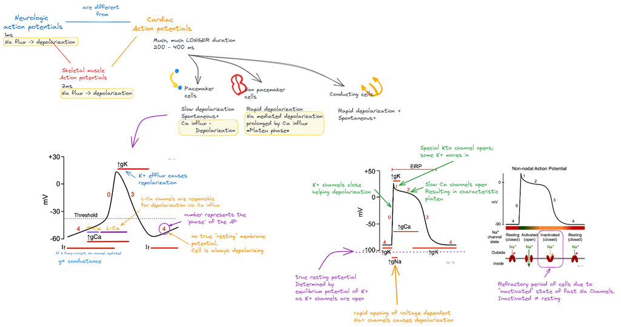

## Electrolyte effects on ECG

**Hyperkalemia**  
EKG changes progress from peaked T-waves to **widened QRS and** eventually to ventricular tachycardia, fibrillation or pulseless electrical activity arrest. These progressive changes can correlate with rising potassium levels. For example, **peaked T waves might correspond with a potassium level of approximately 6 mmol/L,** whereas cardiac arrest generally occurs at higher levels.

**Hypercalcaemia**  
The most common EKG finding associated with hypercalcemia is **shortening of the QT interval**. In severe cases, Osborn or J waves might be seen or ventricular fibrillation might ensue. Recognition of these EKG findings can prompt urgent treatment.

**Hypocalcemia**  
The most common finding on EKG in patients with hypocalcemia is a **prolonged QT interval.**

https://www.ahajournals.org/doi/10.1161/CIRCULATIONAHA.105.166563

doi.org/10.1016/0002-9149(63)90255-8

**Hypermagnesaemia**

# Tumour markers

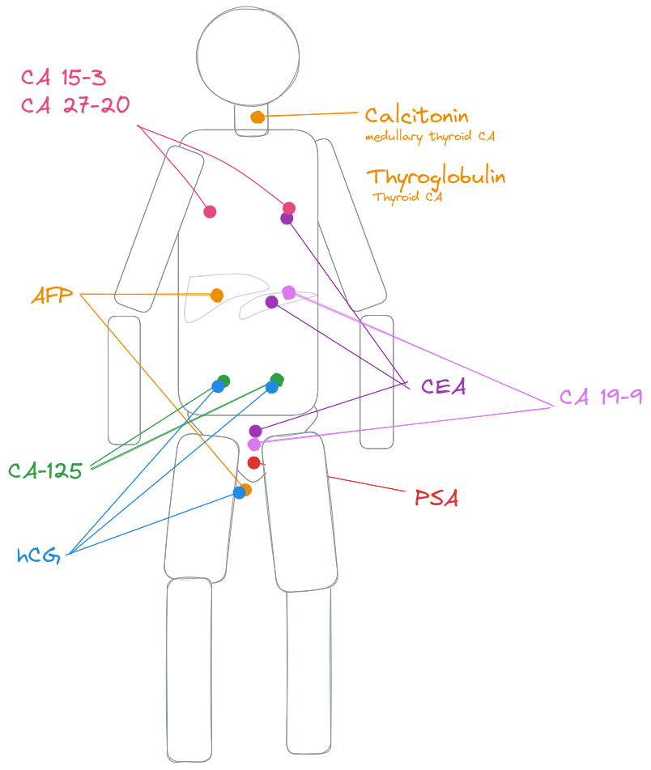

> [!TIP] GPT answer:  
> Certainly! Here is a list of common tumor markers and the tumors they are commonly associated with:
> 1. Prostate-Specific Antigen (PSA) - Prostate cancer
> 2. Carcinoembryonic Antigen (CEA) - Colorectal cancer, pancreatic cancer, lung cancer
> 3. Alpha-fetoprotein (AFP) - Liver cancer, germ cell tumors, particularly testicular cancer
> 4. CA-125 - Ovarian cancer
> 5. CA 19-9 - Pancreatic cancer, colorectal cancer
> 6. CA 15-3 - Breast cancer
> 7. CA 27-29 - Breast cancer
> 8. Human Chorionic Gonadotropin (hCG) - Germ cell tumors, particularly testicular cancer, ovarian cancer, ?lung CA
> 9. Calcitonin - Medullary thyroid cancer
> 10. Thyroglobulin - Thyroid cancer (papillary and follicular)
> 11. Neuron-Specific Enolase (NSE) - Neuroendocrine tumors, small cell lung cancer
> 12. Chromogranin A - Neuroendocrine tumors
> 13. S-100 Protein - Melanoma, neuroendocrine tumors
> 14. Human Epidermal Growth Factor Receptor 2 (HER2) - Breast cancer, gastric cancer
> 15. Epidermal Growth Factor Receptor (EGFR) - Non-small cell lung cancer, colorectal cancer
> 16. 5 HIA - carcinoid tumour
> 17. Carcinoid tumors are of neuroendocrine origin and derived from primitive stem cells in the gut wall, especially the appendix.

BRCA1 and BRCA2 - breast **and** ovarian cancer.

# Inflammatory bowel disease

> [!TIP] A great summary!  
> [Source](https://www.hopkinsmedicine.org/gastroenterology_hepatology/_docs/_pdfs/small_large_intestine/crohns_disease.pdf)

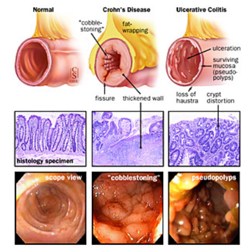

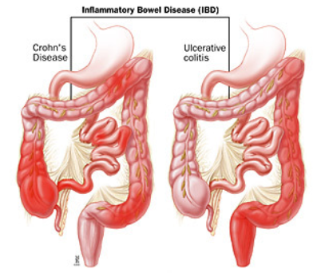

> [!INFO] Differentiation of disease is vital to determine the potential effectiveness of surgery!  
> resection is curative in UC but disease recurs after resection in Crohn's

| Feature | Crohn's Disease | Ulcerative Colitis |
| --- | --- | --- |
| presentation | Abdominal pain + perianal disease | GI bleeding |
| Endoscopy | Cobblestones + linear ulcers | Diffuse *continuous* involvement, pseudopolyps |
| Radiography | Fistulae | No fistulae |
| Distribution | (potentially mouth to anus) Terminal ileal involvement Or ileocolitis, skip lesions(+) | No ileal involvement (backwash ileitis possible) |
| Rectal involvement | Possible, may spare the rectum | Rectum always involved |
| Pathology | Transmural involvement(+) (wall to serosa), Granulomas (+) | mucosal and submucosal inflammation |
|  | Serositis(+) | **Crypt abscesses** – **Crypt abscesses** are more common in UC than CD |
| Management | Resection not curative | Colectomy eliminates illness |
| Epid | Develops in teen and twenties |  |
| Complications | Intestinal obstruction / perforation |  |
|  | Extraintestinal manifestations | Toxic megacolon! |

### Extraintestinal manifestations of Crohn's disease

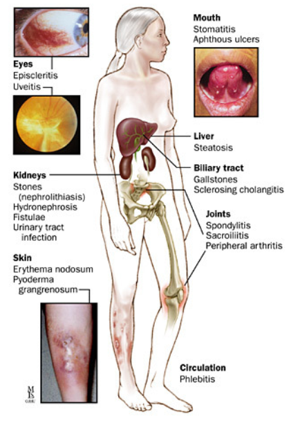

1. Migratory arthitis - appendicular skeleton. Parallels intestinal disease. Treatment of intestinal disease resolves arthritis.
2. Perichonlantitis - seen on ERCP or MRCP.
3. Kidney stones
4. Bowel inflammation -> ureteric obstruction and hydronephrosis
5. Fistulas

# Immunoglobulin classes

#2023BSQ Q49

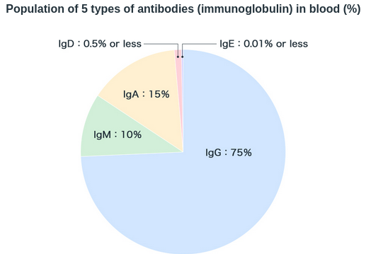

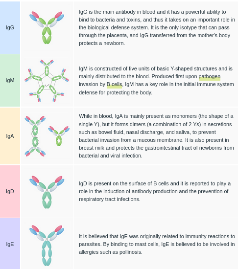

[Source](https://www.kyowakirin.com/antibody/basics/isotypes.html)

• Inappropriate storage temperature of blood samples [13] -> cold temperatures inhibit Na/K pump  
contaminants : EDTA

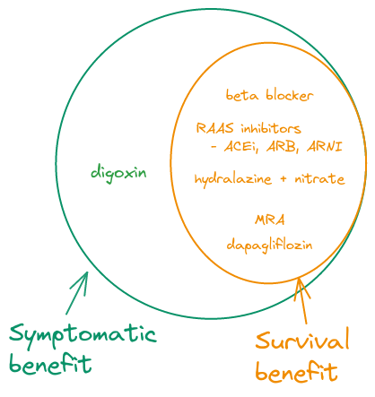

- [[General Pharmacology#Digoxin|Digoxin]] (rarely used for HF) #2022BSQ Q39 <- click the link
- ivabradine used to lower HR if patient is in SR+ and rate > 70 despite maximum beta blocker. (blocks funny channel current -> used in patients in sinus rhythm)
- ISDN + hydralazine

> Cardiac glycosides reversibly inhibit the sodium-potassium-ATPase, causing an increase in intracellular sodium and a decrease in intracellular potassium.

Overall effects : increased contractile velocity (increased contractility) and decreased heart rate.  
1️⃣ Heart failure - *inhibition of Na/K ATPase* -> increased intra-myocyte sodium -> decreased Na calcium exchange -> reduced secretion of calcium -> increased intracellular calcium -> contractility increased.  
However, elevated intracellular calcium also increases risk of arrhythmias.

2️⃣ In patients with HF, [digoxin](https://www.uptodate.com/contents/digoxin-drug-information?search=digoxin&topicRef=122165&source=see_link) also inhibits sympathetic outflow and augments parasympathetic tone.  
Increased parasympathetic tone to the SA node and AV node ->  
(via hypersensitization of carotid sinus baroreceptors, central stimulation, increased vagal output, and possible potentiation of the effect of acetylcholine on the sinoatrial [SA] node) -> slowing the firing of the SA node and prolonging conduction at the atrioventricular (AV) node. -> *supratherapeutic doses can cause sinus brady, AV block, arrhythmias*  
Is a water soluble drug (renally excreted) ?but has large volume of distribution - Distributed within skeletal and cardiac **muscle**. Patients with *low muscle mass (elderly)* or *renal failure* will need loading dose adjustment.  
*Drug has a large Vd. so it's makes sense that it exerts it's effects on muscle*.  
Especially hypokalemia or hypomagnesemia can potentiate toxicity.  
Hypercalcemia can increase risk of toxicity. Hypocalcemia and nullify digoxin effects. -> maintain normal electrolyte levels.  
Renal dysfunction increases digoxin levels and often precipitate toxicity!  
*Acute toxicity* is uncommon - Hyperkalemia (inhibition of Na/K ATPase), hypomagnesemia, hypoxia will predispose to exagerrated action of digoxin. - Correct before administration.  
confusion and weakness is **COMMON**  
Hypokalemia  
Symptoms - GI: N/V/D Dizziness, *CNS may be prominent :* Confusion, Delirium

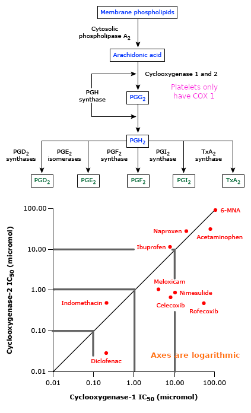

> 1. Early phase - Airway narrowing due to predominantly ASM mediated bronchoconstriction due mast cell released histamine + other mediators
> 2. Late phase - More airway narrowing due to further bronchoconstriction + local inflammation and oedema -> stimulated by inflammatory cells migrating to the mucosa during the late phase
1. Contraction of airway smooth muscle. <-mast cell and eosinophil mediators, such as **leukotrienes C4, D4, and E4** and **histamine**, are potent *bronchoconstrictors*  
   Another **defining feature** of asthma = exagerrated reversible airway obstruction *due to ASM contraction* due to physical, chemical or environmental stimuli. What causes airway smooth muscle to become hyper responsive to these stimuli is not known. Airway remodelling and altered function and mass of ASM could play a part.  
   **Mast cell activation due to various other effectors is main factor in pathogenesis of asthma**.  
   2. These **directly stimulate smooth muscle** -> 🛑**Bronchoconstriction**🛑
   1. monocytes, dendtric cells, neutrophils <- **innate** immune system

## Molecular basis of pathogenesis

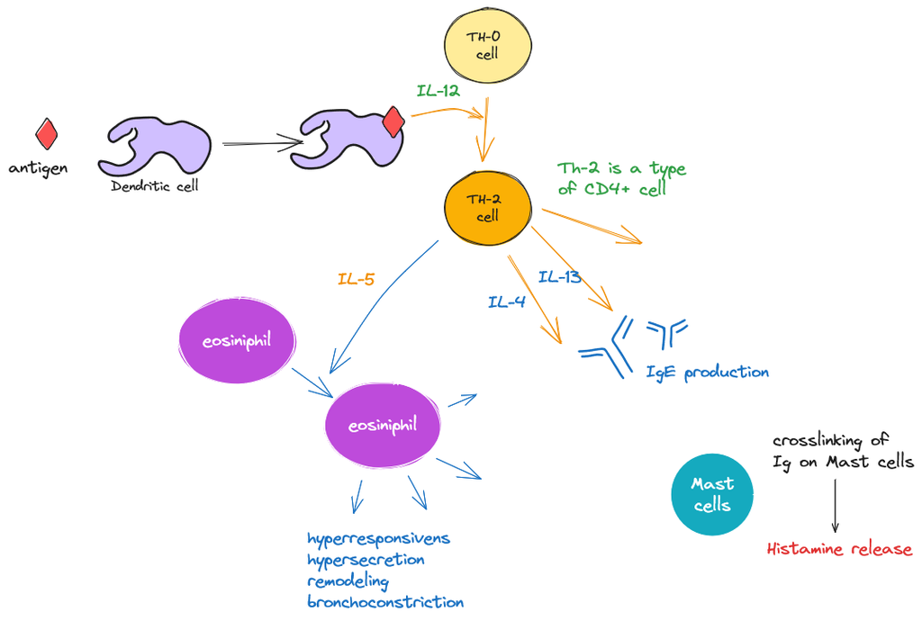

1. Beta agonist : bind smooth muscle receptors -> increased cAMP -> reduce Ca -> inhibition of contraction.
   1. Beta agonists only inhibit the smooth muscle contraction; they do NOT counteract bronchial hyper-responsiveness.
   2. They also *prevent mast cell degranulation*
   3. Salmeterol and formoterol have lipid ligands which anchor them to the cell and increase duration of action.
2. Muscarinic antagonists
   1. Short acting - iptratropium, long acting - tiotropium
   2. Block M1,M2 and M3 receptors.
   3. M1 - in parasympathetic ganglions, M2 - on post synaptic membrane of parasympathetic synapses, M3 - on effector cells (i.e smooth muscle, mucous cells)
   4. Biggest effect in asthma is from blocking M3 receptors.

# Regulation of Respiration

#2022BSQ

> [!TIP] Overview  
> There are chemical and non chemical stimuli for regulation of respiratoion.  
> Chemical stimuli provide the baseline inputs for regulation which are then modified by the non chemical stimuli.  
> Respiratory regulation is done to maintain PCO2, PO2 and pH.  
> The sensors in the system are central and peripheral chemoreceptors. They are sensitive to different parameters.  
> Input is integrated in the medulla.  
> Effectors are the respiratory muscles.  
> Since wider inspired PO2s can be tolerated by the body, the main regulators of respiratory drive in most states are PCO2 and pH.  
> PO2 can trigger respiration if PO2 drops very low.

[Anaemia doest not affect PaO2 in normal respiratory physiology](https://www.wellingtonicu.com/Data/ABG/ABG%20and%20oxygen%20content.pdf)

> Therefore, the receptors are not stimulated in conditions such as anemia or carbon monoxide poisoning, in which the amount of *dissolved O2* in the blood reaching the receptors is generally normal, even though the combined O2 in the blood is markedly decreased. - Ganong

## Chemical regulation of respiration

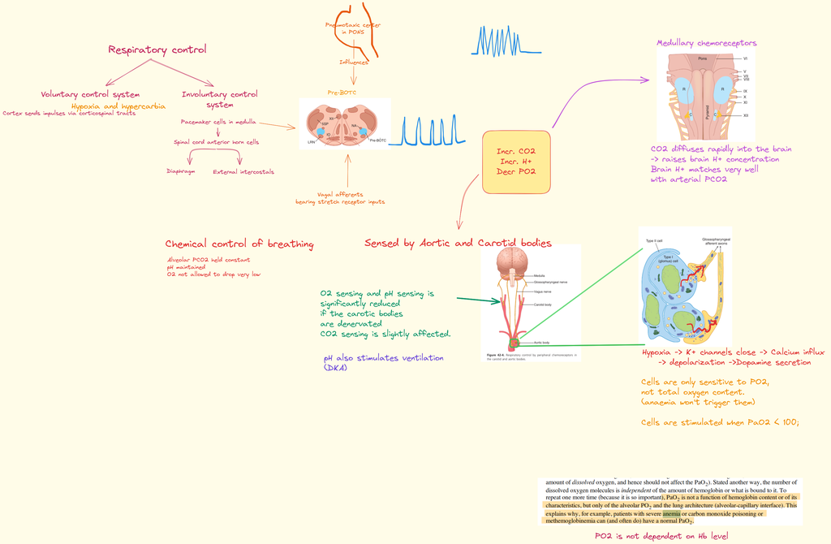

These afferent signals stimulate the respiratory centers (PreBOTC) in the medulla to increase the rate and depth of respiration.

| Central chemoreceptors | Peripheral chemoreceptors |
| --- | --- |
| Ventral surface of medulla | Aortic and carotid bodies |
| Sense pH (via PCO2) diffusion | Sense low PO2 and high PCO2 and probaly low pH |
| do NOT sense O2 | Only sensor for O2 level |
| Can be desensitized | Cannot be desensitized |

Source- desensitization  
Illustration of the above: Denervation of peripheral chemoreceptor will abolish PO2 response and reduce pH response. PCO2 response will be only slightly reduced.

Many graphs illustrate the influece of PO2, pCO2 and pH on respiratory rate:

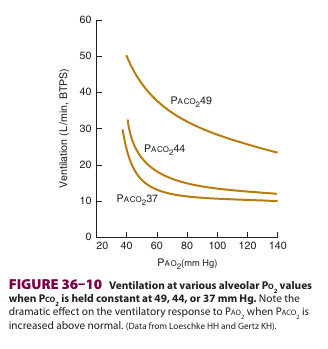

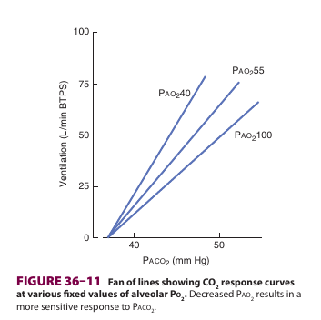

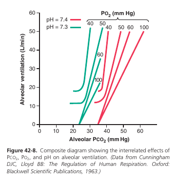

Overall, PCO2 exerts the most influence on respiratory control.  
why?  
PaO2 sensitive glomus cells in the peripheral chemoreceptors increase firing as soon as the PO2 drops below 100.  
However this doesn't translate into increased respiratory rate because:

1. Desaturated Hb is less acidic -> increases blood pH -> decreases pH based respiratory drive.
2. increased ventilation due to hypoxia -> CO2 washout -> decreased pCO2 and increased pH -> inhibition of respiratory drive.

PO2 based resiratory drive overrides the above two factors when PO2 drops to 'dangerously' low levels (i.e PaO2 approx 60.)  
Lower PO2 levels will directly *inhibit* the respiratory center.

*Not affected by BCG vaccination.*

# Odds and risk

**Measures of association** between an exposure and an outcome.
Used when researches want to know whether the presence of a risk factor (or an intervention) alters the risk of an outcome.
$$
\Large{\mathbf{Risk} = \frac{outcome\ of\ interest}{all\ possible\ outcomes}}
$$
$$
\Large{\mathbf{Odds} = \frac{probability\ of\ an\ event\ occuring}{probability\ of\ event\ not\ occuring}}
$$
For example,
$$
{\mathbf{Risk\ of\ Death} = \frac{Deaths}{Deaths + Survivors}}
$$
$$
{\mathbf{Odds\ of\ Death} = \frac{Deaths}{Survivors}}
$$
For rare events,
a/(a+b) (i.e the *risk*) ≈ a/b (ie *the odds*) (since a is small) => for rare events, odds and risk have similar values.

> Therefore, though “odds” does not represent true risk, its value is close to risk when the event rates are low.

## Relative risk:

The relative risk (also known as risk ratio [RR]) is
the ratio of risk of an event in one group (e.g., exposed group) versus the risk of the event in the other group (e.g., nonexposed group).
$$
RR=\frac{risk\ of\ event\ in\ one\ group}{risk\ of\ event\ in\ other\ group}
$$

## Odds ratio:

Similar concept as relative risk but uses the odds instead of risk.
$$
OR=\frac{odds\ of\ event\ in\ one\ group}{odds\ of\ event\ in\ other\ group}
$$

## Interpretation

RR(OR) = 1.0 => no difference in risk or ords  
RR(OR) > 1.0 => increase in risk among exposed  
RR(OR) < 1.0 => decreased risk among exposed.

For these to apply, the exposed group would have to be in the numerator of the fraction.

**The relationship of OR and RR is complex.**

- Odds ratio is usually further from 1.0 than relative risk, for a given dataset. (i.e it exaggerates the relationship between exposure and outcome)
- As mentioned above, for rare events, OR and RR will be similar. As event rate increases, the OR and RR diverge.

## When to use OR Vs. RR

In retrospective studies (**case-control**) studies, the total number of people "at risk" is not available. RR cannot be calculated. OR must be used.

> [!INFO] Case control -> OR

In prospective studies (**cohort studies**) RR AND OR can be used.

# Absolute risk reduction

"Whether the observed effect of an intervention is *clinically important*"  
We use

1. absolute risk reduction
2. relative risk reduction
3. and number needed to treat  
   to quantify the **effect size**.

## Examples

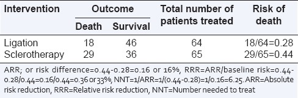

risk of death for 'ligation' patients : 18/64 = 0.28  
risk of death for 'sclerotherapy' patients: 29/65 = 0.44  
Absolute risk reduction = 44% - 28% = 16%.  
That is "*the proportion of patients who are spared the adverse outcome as a result of having received the experimental rather than the control therapy*".

It makes more sense to compare the absolute risk reduction in terms of the baseline risk. -> [[#Relative risk reduction]]

# Relative risk reduction

> In the above example, the baseline risk of death was 44% and ligation with an ARR of 16%reducedthis risk to 28%, which is nearly two-third (=0.28/0.44 = 0.636 or 64%) of the baseline risk. This is a medium-sized “relative” effect. However, if the baseline risk of death had been 20%, then a 16% ARR would bring the risk down to 4%, i.e. to about one-fifth of the original risk, a much bigger change in relative terms

$$
\large{RRR = \frac{ARR}{risk\ in\ \mathbf{control}\ group}}
$$
RRR = *"percentage of baseline risk that is removed as a result of the new therapy"*

Relative risk reduction from both 80% to 40% and 2% to 1% is 50%.  
I.e relative risk reduction alone isn't very meaningful. Absolute risk reduction should be reported in a study.

# Number needed to treat

$$
\Large{NNT=\frac{1}{ARR}}
$$

# Study types

## Case control study

[Source](https://www.ncbi.nlm.nih.gov/pmc/articles/PMC1706071/)  
[Source](https://www.ncbi.nlm.nih.gov/pmc/articles/PMC1706071/)

Designed to help determine if an exposure is associated with an outcome.  
Case control studies *start with an outcome*.  
Step 1: identify the cases (i.e people how have the *outcome*)  
Step 2: Identify the controls (i.e people who are *free of the outcome*)  
Step 3: Look retrospectively to see the frequency of exposure in each group.

| Advantage | Disadvantages |
| --- | --- |
| Cheap and easy | possible to "over match" controls |
| Good for rare diseases | "matching criteria" cannot be analysed as risk factors |
| Quick -> good for analysing outbreaks | **DO NOT prove CAUSATION** ; only association |
| Can study multiple exposures | cannot generate incidence data |
|  | Subject to bias |

**Cases**: a rigorous definition for a 'case' should be determined before proceeding with the study.  
**Controls:** Should be similar to the cases as judged by *specified* **matching criteria.** (i.e patients of the same age, sex or those who sent to the same hospital). The control group should overall have a similar risk of the outcome as the case group.  
*Matching* controls will mitigate the effects of **confounders.**

> [!INFO] Counfounding variable:  
> **Counfounding variable** = A variable which is associated with the exposure *AND* is a cause of the outcome

Power of the study can be increased by enrolling **2 controls** per case. (but not more, because of how statistics works)

> Correlation only ; not causation  
> Consider a case-control study intended to establish an association between the use of traditional eye medicines (TEM) and corneal ulcers. TEM might cause corneal ulcers but it is also possible that the presence of a corneal ulcer leads some people to use TEM. *The temporal relationship between the supposed cause and effect cannot be determined by a case-control study.*